WHITE WINE INVESTIGATION by Franz Hastrup-Nielsen  
date: May 15, 2018  
output: html_document  
========================================================

This report is going through the steps of Exploratory Data Analysis (EDA) using a dataset that contains information about white wines and their associated quality.

# Univariate Plots Section

Input variables and short explanation:  
1 - fixed.acidity fixed acidity (tartaric acid - g / dm^3)  
2 - volatile.acidity volatile acidity (acetic acid - g / dm^3)  
3 - citric.acid citric acid (g / dm^3)  
4 - res.sugar residual sugar (g / dm^3)  
5 - chlorides chlorides (sodium chloride - g / dm^3  
6 - free.so2 free sulfur dioxide (mg / dm^3) 7 - total.so2 total sulfur dioxide (mg / dm^3)  
8 - density density (g / cm^3)  
9 - pH pH  
10 - sulphates sulphates (potassium sulphate - g / dm3)  
11 - alcohol alcohol (% by volume)  
Output variable (based on sensory data):  
12 - quality quality (score between 0 and 10)

```
## [1] 4898   13
```

The dataset includes 4898 rows of wines and 12 columns assigned to each wine.

Here are the variables and a summary of the dataset to be investigated:

```
##  [1] "X"                "fixed.acidity"    "volatile.acidity"
##  [4] "citric.acid"      "res.sugar"        "chlorides"
##  [7] "free.so2"         "total.so2"        "density"
## [10] "pH"               "sulphates"        "alcohol"
## [13] "quality"
```

```
##   X fixed.acidity volatile.acidity citric.acid res.sugar chlorides
## 1 1           7.0             0.27        0.36      20.7     0.045
## 2 2           6.3             0.30        0.34       1.6     0.049
## 3 3           8.1             0.28        0.40       6.9     0.050
## 4 4           7.2             0.23        0.32       8.5     0.058
## 5 5           7.2             0.23        0.32       8.5     0.058
## 6 6           8.1             0.28        0.40       6.9     0.050
##   free.so2 total.so2 density   pH sulphates alcohol quality
## 1       45       170  1.0010 3.00      0.45     8.8       6
## 2       14       132  0.9940 3.30      0.49     9.5       6
## 3       30        97  0.9951 3.26      0.44    10.1       6
## 4       47       186  0.9956 3.19      0.40     9.9       6
## 5       47       186  0.9956 3.19      0.40     9.9       6
## 6       30        97  0.9951 3.26      0.44    10.1       6
```

```
##        X        fixed.acidity    volatile.acidity  citric.acid
##  Min.   :   1   Min.   : 3.800   Min.   :0.0800   Min.   :0.0000
##  1st Qu.:1225   1st Qu.: 6.300   1st Qu.:0.2100   1st Qu.:0.2700
##  Median :2450   Median : 6.800   Median :0.2600   Median :0.3200
##  Mean   :2450   Mean   : 6.855   Mean   :0.2782   Mean   :0.3342
##  3rd Qu.:3674   3rd Qu.: 7.300   3rd Qu.:0.3200   3rd Qu.:0.3900
##  Max.   :4898   Max.   :14.200   Max.   :1.1000   Max.   :1.6600
##    res.sugar        chlorides          free.so2        total.so2
##  Min.   : 0.600   Min.   :0.00900   Min.   :  2.00   Min.   :  9.0
##  1st Qu.: 1.700   1st Qu.:0.03600   1st Qu.: 23.00   1st Qu.:108.0
##  Median : 5.200   Median :0.04300   Median : 34.00   Median :134.0
##  Mean   : 6.391   Mean   :0.04577   Mean   : 35.31   Mean   :138.4
##  3rd Qu.: 9.900   3rd Qu.:0.05000   3rd Qu.: 46.00   3rd Qu.:167.0
##  Max.   :65.800   Max.   :0.34600   Max.   :289.00   Max.   :440.0
##     density             pH          sulphates         alcohol
##  Min.   :0.9871   Min.   :2.720   Min.   :0.2200   Min.   : 8.00
##  1st Qu.:0.9917   1st Qu.:3.090   1st Qu.:0.4100   1st Qu.: 9.50
##  Median :0.9937   Median :3.180   Median :0.4700   Median :10.40
##  Mean   :0.9940   Mean   :3.188   Mean   :0.4898   Mean   :10.51
##  3rd Qu.:0.9961   3rd Qu.:3.280   3rd Qu.:0.5500   3rd Qu.:11.40
##  Max.   :1.0390   Max.   :3.820   Max.   :1.0800   Max.   :14.20
##     quality
##  Min.   :3.000
##  1st Qu.:5.000
##  Median :6.000
##  Mean   :5.878
##  3rd Qu.:6.000
##  Max.   :9.000
```

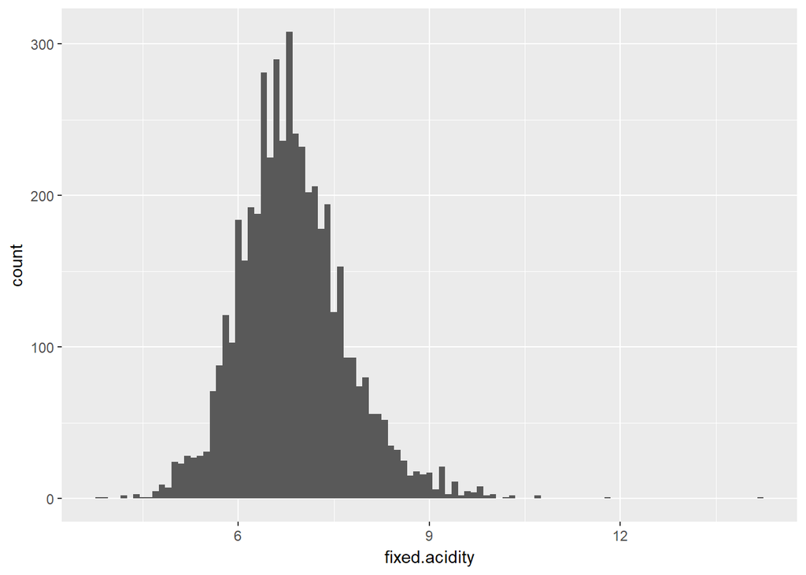

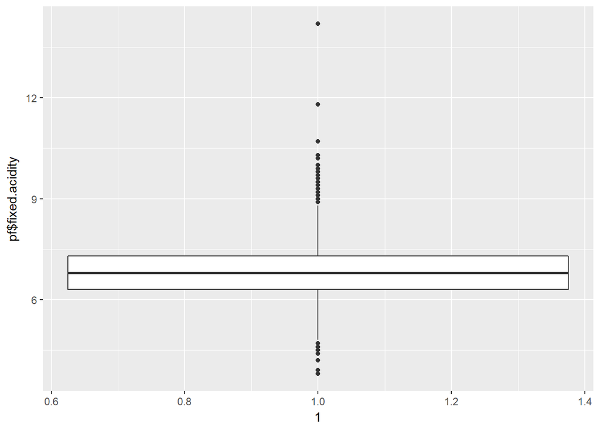

```
##    Min. 1st Qu.  Median    Mean 3rd Qu.    Max.
##   3.800   6.300   6.800   6.855   7.300  14.200
```

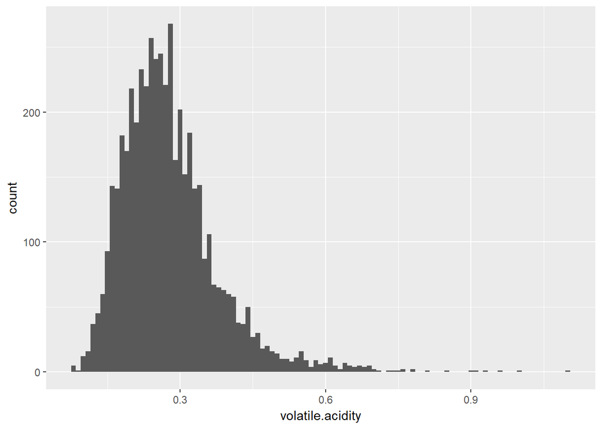

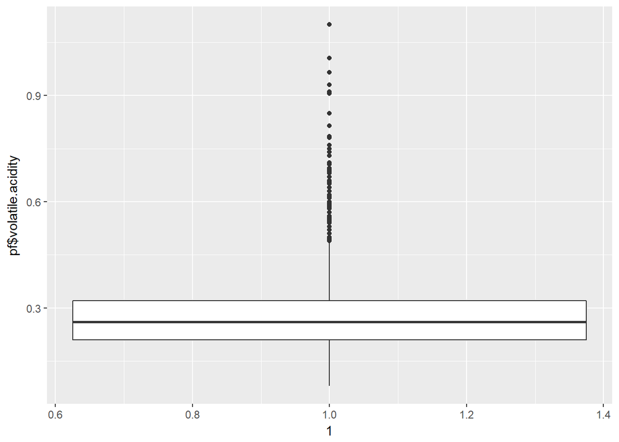

```
##    Min. 1st Qu.  Median    Mean 3rd Qu.    Max.
##  0.0800  0.2100  0.2600  0.2782  0.3200  1.1000
```

Both the fixed and volatile acidity seems to be normally distributed with a positive skew, as a small tail forms towards the higher values. As the boxplot shows, there seems to be a larger range of high values for both cases.

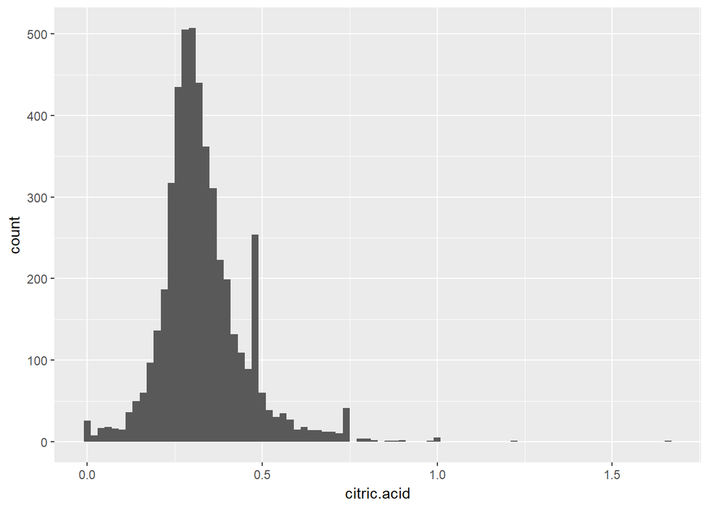

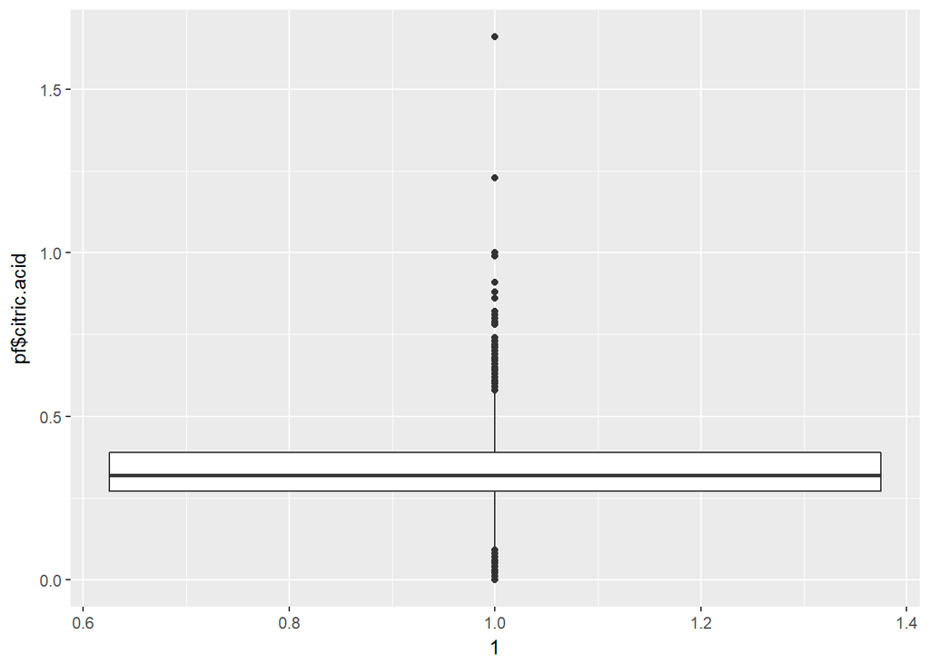

```
##    Min. 1st Qu.  Median    Mean 3rd Qu.    Max.
##  0.0000  0.2700  0.3200  0.3342  0.3900  1.6600
```

Citric acid is normally distributed with a positive skew due to a longer tail towards the higher values. Furthermore, it seems that two values on the right side is more prevalent close to 0.5 and 0.75. This could need further investigation. The boxplot shows the positive skew as the median is closer to the 25% quantile.

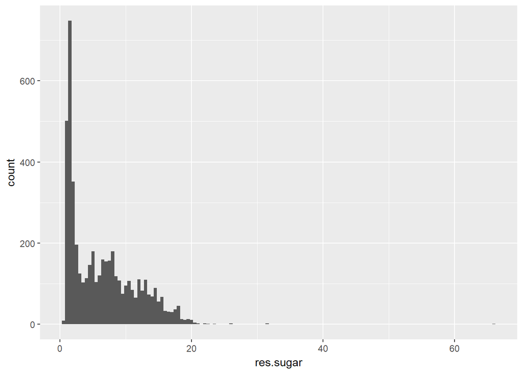

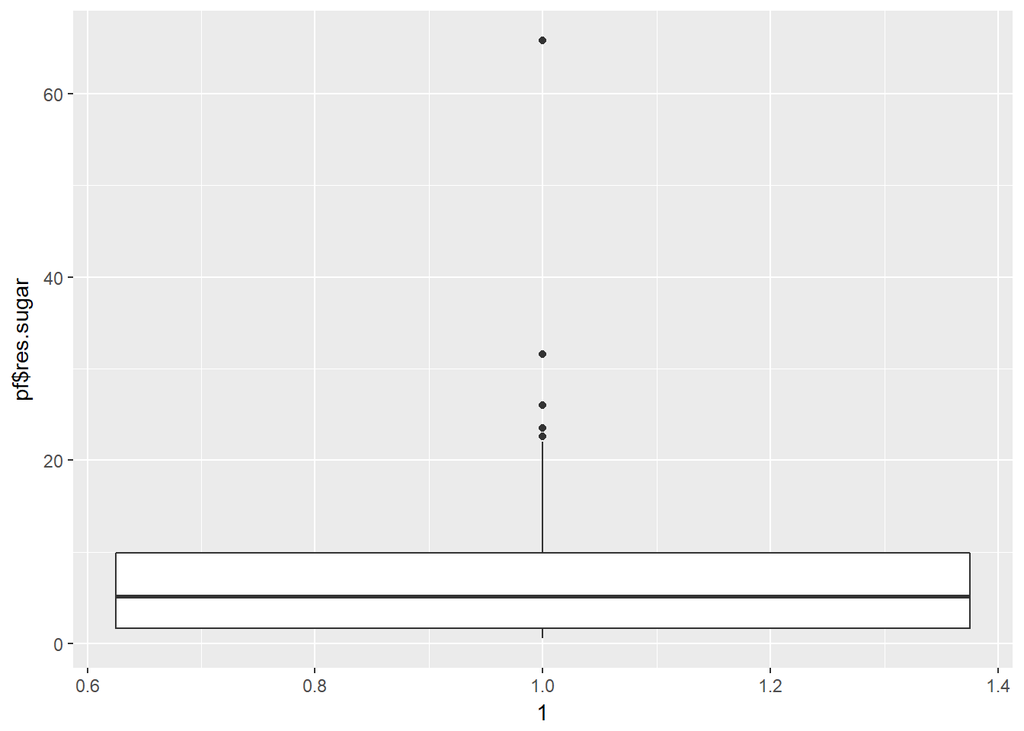

```
##    Min. 1st Qu.  Median    Mean 3rd Qu.    Max.
##   0.600   1.700   5.200   6.391   9.900  65.800
```

Residual sugar has a normal distribution with positive skew and some outliers at very high values as indicated by the boxplot.

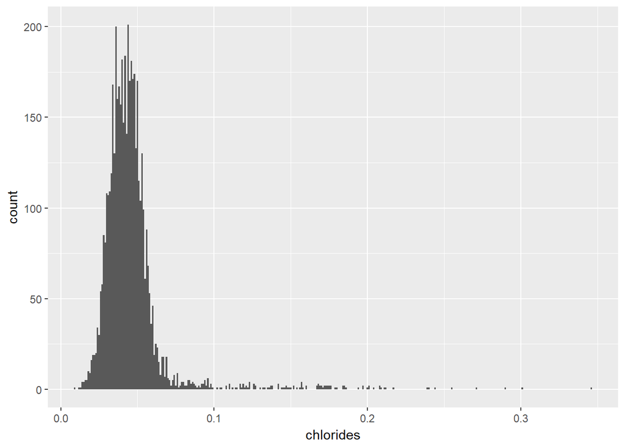

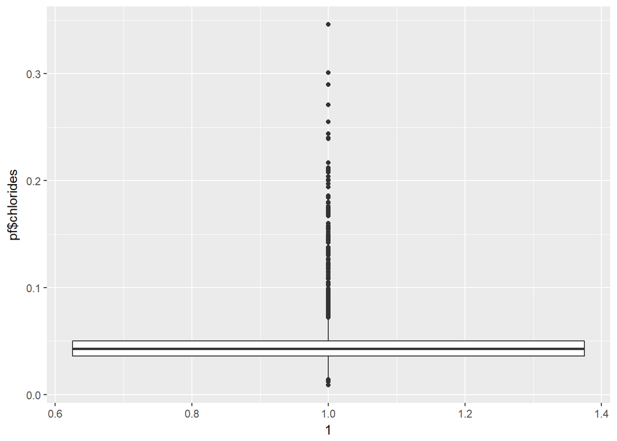

```
##    Min. 1st Qu.  Median    Mean 3rd Qu.    Max.
## 0.00900 0.03600 0.04300 0.04577 0.05000 0.34600
```

Chlorides behaves like the rest of the data with a normal distribution with a positive skew. With a low binwidth the distribution could be displaying some bi-modal behavior

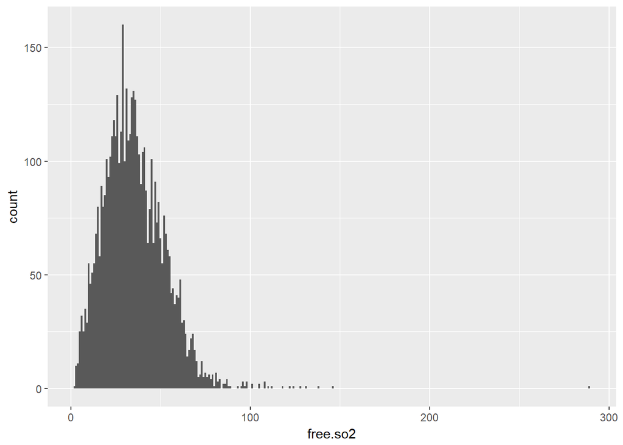

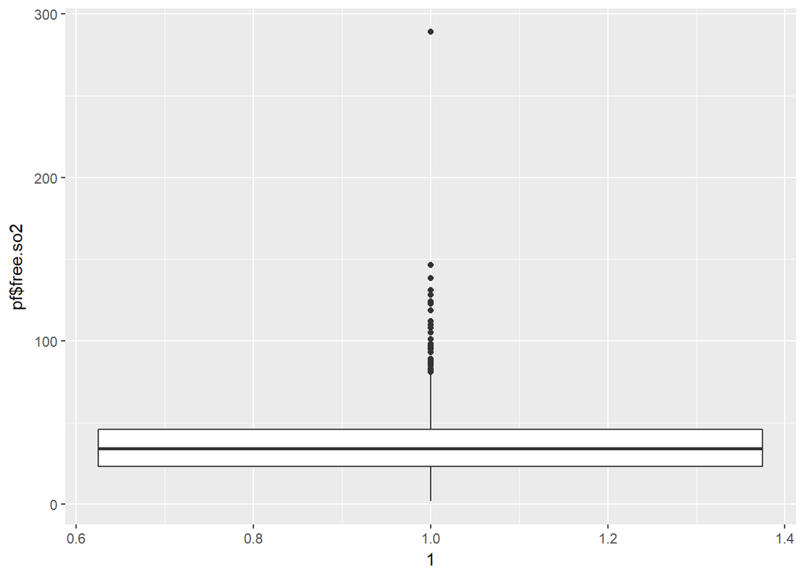

```
##    Min. 1st Qu.  Median    Mean 3rd Qu.    Max.
##    2.00   23.00   34.00   35.31   46.00  289.00
```

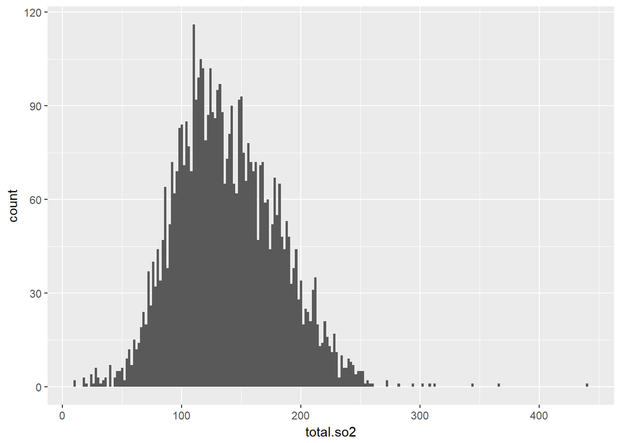

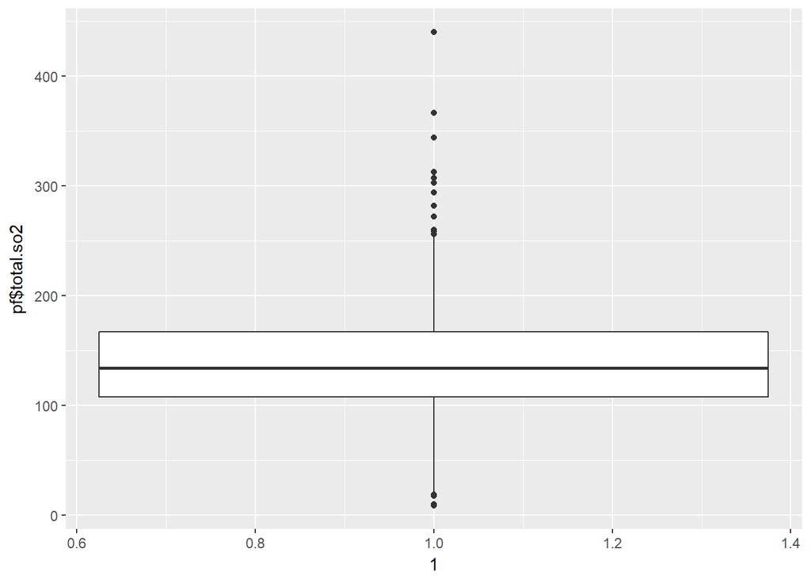

```
##    Min. 1st Qu.  Median    Mean 3rd Qu.    Max.
##     9.0   108.0   134.0   138.4   167.0   440.0
```

The free and total sulfur dioxide are both normally distributed with a positive skew

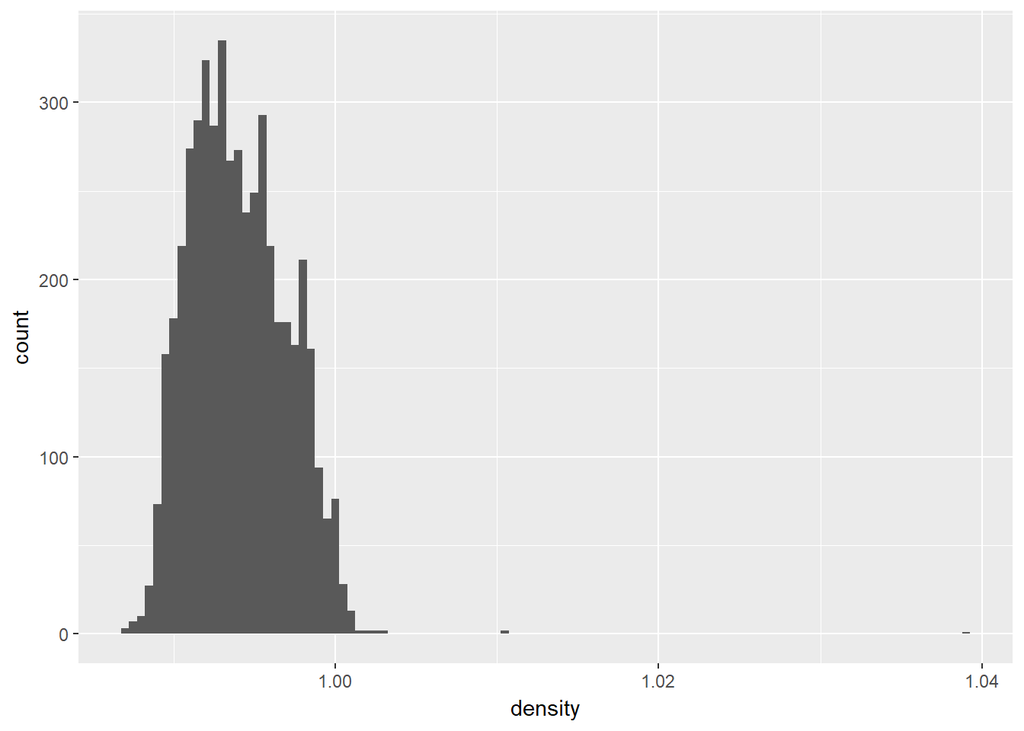

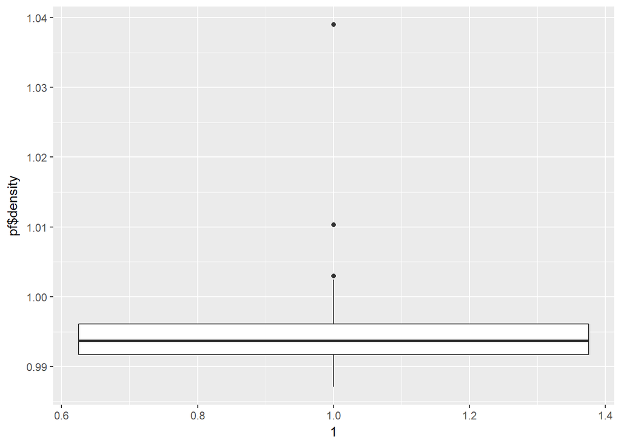

```
##    Min. 1st Qu.  Median    Mean 3rd Qu.    Max.
##  0.9871  0.9917  0.9937  0.9940  0.9961  1.0390
```

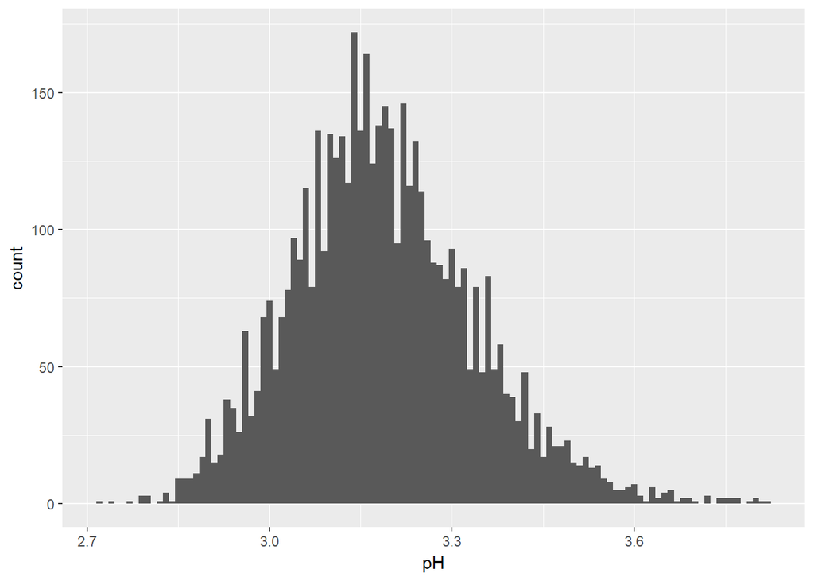

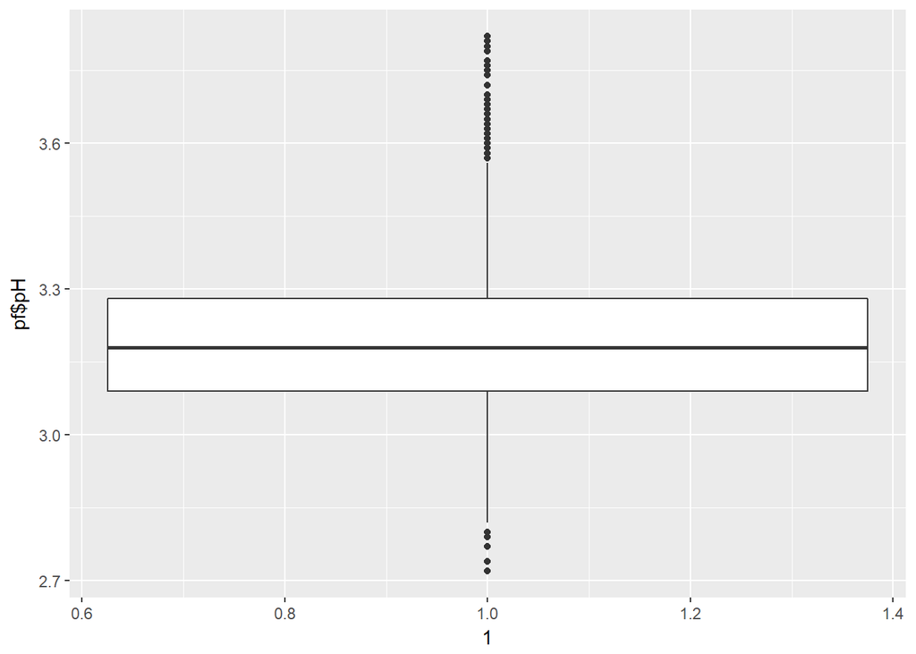

```
##    Min. 1st Qu.  Median    Mean 3rd Qu.    Max.
##   2.720   3.090   3.180   3.188   3.280   3.820
```

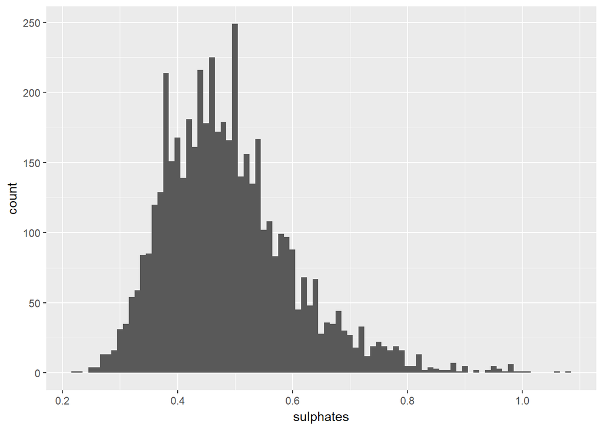

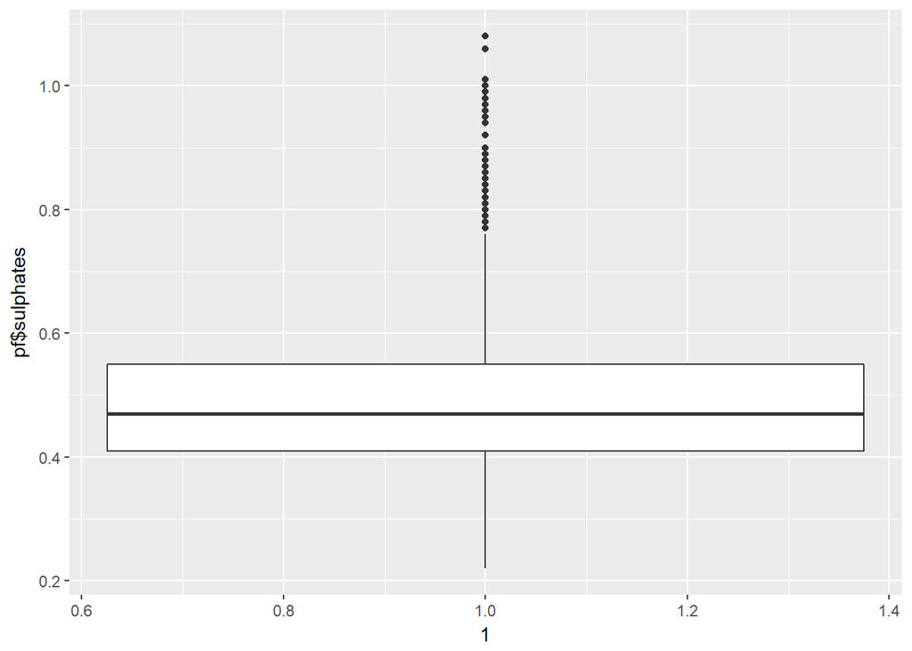